# Model Selection

*Present your question and state the base model you plan to extend. You should present and explain each of the equations, either in discrete or continuous time, that describe the base system and explain how these equations describe the dynamics. Describe your model extension and justify how it will answer your question. You should give a written explaination and present the updated equations for your extended model. Clearly state any assumptions you make in your model. You can use a flow chart (if it’s applicable to your model) or other visual aid in your response.*

**"How would the behaviour of predators affect their interactions with prey if the predator's behviours were influenced by quantum mechanics principles?"**

For this question, the Lotka-Volterra predator-prey model will be used. This question explores the interactions of what happens if the ways predators hunt, avoid dangers, or make decisions are based on quantum states, which could include elements such as randomness or other non-classical physics traits. The idea here could be that certrain behaviours or decision-making processes in predators are influenced by quantum mechanics, perhaps through phenomena like quantum superposition or entanglement. This could theoretically allow predators to exist in multiple states or make decisions that are based on a probability distribution influenced by quantum effects, rather than being purely deterministic.

For this modified Lotka-Volterra equation, we let $H$ be the prey population and $P$ be the predator population, influenced by quantum behavioral effects.

**Prey Population Dynamics (H):** $$\frac{dH}{dt} = rH - \alpha Q(t)HP$$

**Predator Population Dynamics (P):** $$\frac{dP}{dt} = bQ(t)HP - mP$$

The quantum probability factor $Q(t)$ represents the quantum state of the predator's hunting ability, which affects its efficiency and success rate in real-time. This factor can fluctuate based on quantum mechanic principles like superposition, where it could be modeled as a function that oscillates or varies non-deterministically.

The predation rate $a$ in the Lotka-Volterra model could be modified by this quantum probability factor. Therefore, introducing a new level of unpredictability and variation in the predator-prey relationship.

Some assumptions that were made include:

1. Predator and prey populations are uniformly distributed over the shared habitat between the two species.
2. Quantum mechanics principles, like quantum superposition or entanglement, can directly influence the cognitive or physiological behaviours of predators.
3. Environemntal factors affecting the populations are constant or uniformly distributed.
4. Each individual in the prey population are genetically and behaviourally identical. Same goes to the predator population.
5. Other parameters, like intrinsic growth rate of the prey (r), natural mortality rate of the predators (m), and the baseline conversion efficiency (b) are constants.
6. Reactions of the prey and predator populations to ecological and environmental changes are immediate.

# Discrete Time Analysis

*Now that you have a coupled dynamical system set out, lets try modeling it. Express your dynamical system in the form of difference equations, and then study the behaviour. Do so for a variety of initial conditions and model parameters. Plot and explain your results. Discuss how your results illuminate the question posed in Part 1.*

Firstly, to convert the continuous-time Lotka-Volterra model from Part 1, we will use differential equations. In this case, we can apply Euler's method for a simple numerical solution, where each step represents a time increment $\Delta t$.

**Prey population:** $$ H_{n+1} = H_n + \Delta t \cdot (rH_n - \alpha_n Q_n H_n P_n) $$

**Predator population:** $$ P_{n+1} = P_n + \Delta t \cdot (bQ_n H_n P_n - mP_n) $$

Where:

- $H_n$ represents the prey population at time step $n$.
- $P_n$ represents the predator population at time step $n$.
- $Q_n$ represents the quantum probability factor affecting the predator's efficiency at time step $n$.

We will need to assume that since $Q(t)$ introduces variability based on quantum mechanics, $Q_n$ oscillates between values due to quantum uncertainty, modeled as: $$ Q_n = 0.5 + 0.5 sin(2\pi \omega n \Delta t) $$

Where:

- $\omega$ represents a frequency parameter that determines how quickly the quantum state fluctuates.

```python
import numpy as np
import matplotlib.pyplot as plt
```

For this simulation we will choose the following parameters. We will then simulate this system over a suitable number of time steps and plot the population trajectories of both predators and prey under these varying conditions.

```python
# Parameters
r = 0.1  # Prey growth rate
a = 0.02  # Predation rate
b = 0.1  # Predator efficiency
m = 0.05  # Predator mortality
dt = 0.1  # Time step size
N = 1000  # Number of time steps
omega_values = [0.1, 0.5, 1.0]  # Different quantum fluctuation frequencies
```

The following function simulates the population dynamics over time for given values of $\omega$, which influences the quantum probability factor and iterates through each time step, updating the populations of prey and predators using the difference equations derived from the Lotka-Volterra model modified by the quantum probability factor.

```python
# Initial conditions
H0 = 50  # Initial prey population
P0 = 10  # Initial predator population

def run_simulation(omega):
    H = np.zeros(N)
    P = np.zeros(N)
    Q = 0.5 + 0.5 * np.sin(2 * np.pi * omega * np.arange(N) * dt)  # Quantum probability factor

    H[0] = H0
    P[0] = P0

    # Simulate using difference equations
    for n in range(N - 1):
        H[n+1] = H[n] + dt * (r * H[n] - a * Q[n] * H[n] * P[n])
        P[n+1] = P[n] + dt * (b * Q[n] * H[n] * P[n] - m * P[n])

    return H, P, Q
```

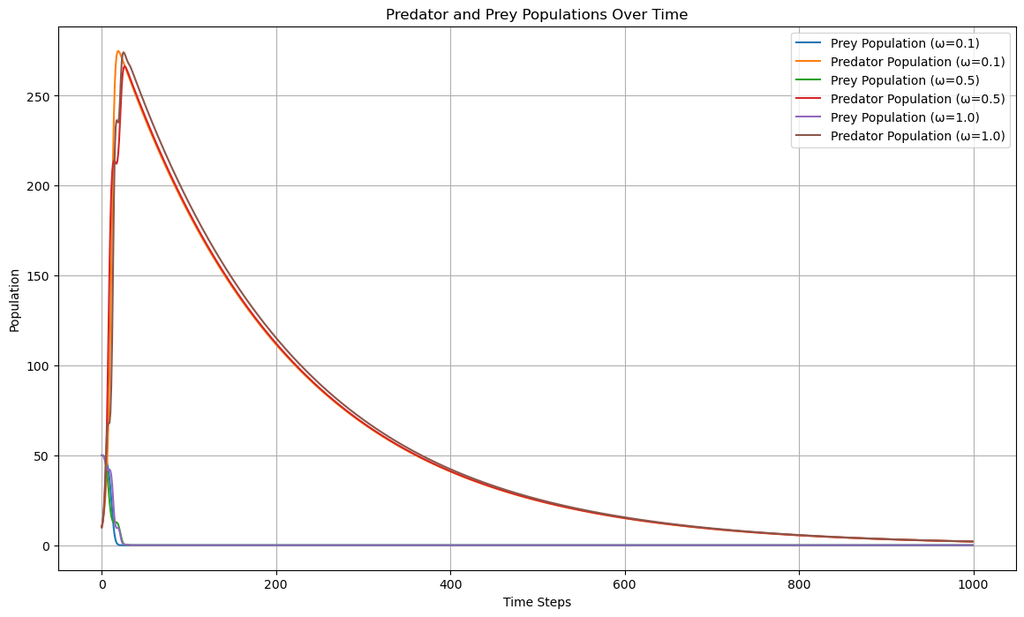

```python
# Plotting
plt.figure(figsize=(14, 8))
for omega in omega_values:
    H, P, Q = run_simulation(omega)
    plt.plot(H, label=f'Prey Population (ω={omega})')
    plt.plot(P, label=f'Predator Population (ω={omega})')

plt.title('Predator and Prey Populations Over Time')
plt.xlabel('Time Steps')
plt.ylabel('Population')
plt.legend()
plt.grid(True)
plt.show()
```

The plot above shows the trajectories of both predators and prey populations over time, under different frequencies ($\omega$) of the quantum fluctuation parameter $Q(t)$.

The question in Part 1 posed was how quantum mechanics principles influencing predator behaviour would affect predator-prey interactions. This model and simulation suggests that the introduction of quantum effects as a fluctuating factor in predator efficiency introduces a layer of uncertainty and non-determinism into classical ecological models. This can lead to more dynamic and potentially unstable ecosystems. This, of course, depends on the nature and frequency of these quantum fluctuations.

Now we will discuss how different initial conditions affect the dynamics of the predator-prey system with quantum influences.

```python
import numpy as np
import matplotlib.pyplot as plt

# Redefine simulation parameters and function after state reset
r = 0.1  # Prey growth rate
a = 0.02  # Predation rate
b = 0.1  # Predator efficiency
m = 0.05  # Predator mortality
dt = 0.1  # Time step size
N = 1000  # Number of time steps

def run_simulation(H0, P0, omega):
    H = np.zeros(N)
    P = np.zeros(N)
    Q = 0.5 + 0.5 * np.sin(2 * np.pi * omega * np.arange(N) * dt)  # Quantum probability factor

    H[0] = H0
    P[0] = P0

    # Simulate using difference equations
    for n in range(N - 1):
        H[n+1] = H[n] + dt * (r * H[n] - a * Q[n] * H[n] * P[n])
        P[n+1] = P[n] + dt * (b * Q[n] * H[n] * P[n] - m * P[n])

    return H, P, Q

# Define a set of different initial conditions and parameters to explore various scenarios
initial_conditions = [
    (50, 10),   # Initial scenario
    (10, 10),   # Lower initial prey population
    (100, 10),  # Higher initial prey population
    (50, 0),    # No initial predators
    (0, 10),    # No initial prey
    (10, 50)    # More predators than prey
]

# Run simulations for each set of initial conditions
results = {}
for idx, (H0, P0) in enumerate(initial_conditions):
    H, P, Q = run_simulation(H0, P0, omega=0.5)  # Using a moderate omega for simplicity
    results[idx] = (H, P, Q, H0, P0)
```

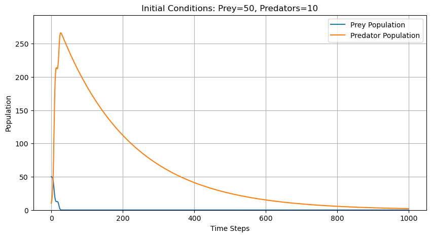

```python
# Intial conditions when prey=50 and predators=10
H, P, Q, H0, P0 = results[0]

plt.figure(figsize=(10, 5))
plt.plot(H, label='Prey Population')
plt.plot(P, label='Predator Population')
plt.title(f'Initial Conditions: Prey={H0}, Predators={P0}')
plt.xlabel('Time Steps')
plt.ylabel('Population')
plt.ylim(0, max(np.max(H), np.max(P)) * 1.1)  # Adjust y-axis limits for better visualization
plt.legend()
plt.grid(True)
plt.show()
```

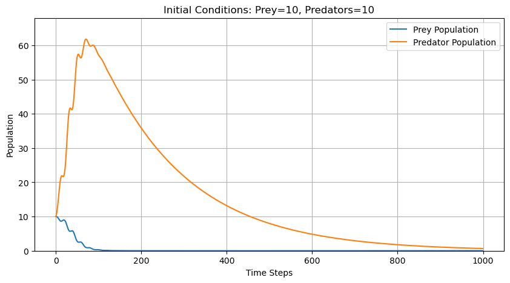

```python
# Intial conditions when prey=10 and predators=10
H, P, Q, H0, P0 = results[1]

plt.figure(figsize=(10, 5))
plt.plot(H, label='Prey Population')
plt.plot(P, label='Predator Population')
plt.title(f'Initial Conditions: Prey={H0}, Predators={P0}')
plt.xlabel('Time Steps')
plt.ylabel('Population')
plt.ylim(0, max(np.max(H), np.max(P)) * 1.1)  # Adjust y-axis limits for better visualization
plt.legend()
plt.grid(True)
plt.show()
```

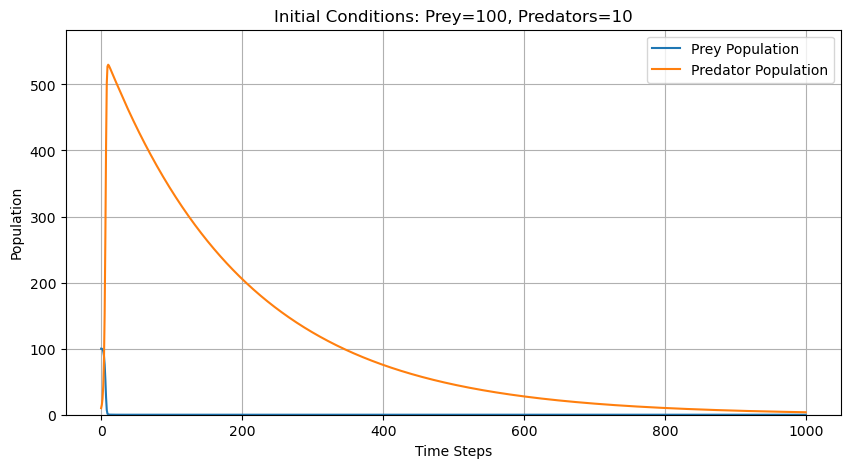

```python
# Intial conditions when prey=100 and predators=10
H, P, Q, H0, P0 = results[2]

plt.figure(figsize=(10, 5))
plt.plot(H, label='Prey Population')
plt.plot(P, label='Predator Population')
plt.title(f'Initial Conditions: Prey={H0}, Predators={P0}')
plt.xlabel('Time Steps')
plt.ylabel('Population')
plt.ylim(0, max(np.max(H), np.max(P)) * 1.1)  # Adjust y-axis limits for better visualization
plt.legend()
plt.grid(True)
plt.show()
```

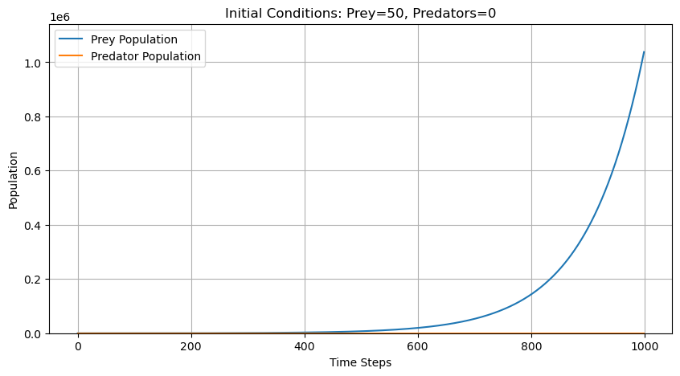

```python
# Intial conditions when prey=50 and predators=0
H, P, Q, H0, P0 = results[3]

plt.figure(figsize=(10, 5))
plt.plot(H, label='Prey Population')
plt.plot(P, label='Predator Population')
plt.title(f'Initial Conditions: Prey={H0}, Predators={P0}')
plt.xlabel('Time Steps')
plt.ylabel('Population')
plt.ylim(0, max(np.max(H), np.max(P)) * 1.1)  # Adjust y-axis limits for better visualization
plt.legend()
plt.grid(True)
plt.show()
```

The plotted graph above allows the prey population to grow unchecked while starting without any predators. This graph showcases a continuous increase in the prey population, which is a little unrealistic in a natural setting but illustrative in this model context. In real ecosystems, other limiting factors such as disease, competition, and carrying capacity would typically prevent such unchecked growth. However, this scenario highlights the ecological role of predators in controlling prey populations and maintaining balance. Without predators, the prey population may grow to unsustainable levels, potentially leading to environmental degradation or collapse due to overconsumption of resources.

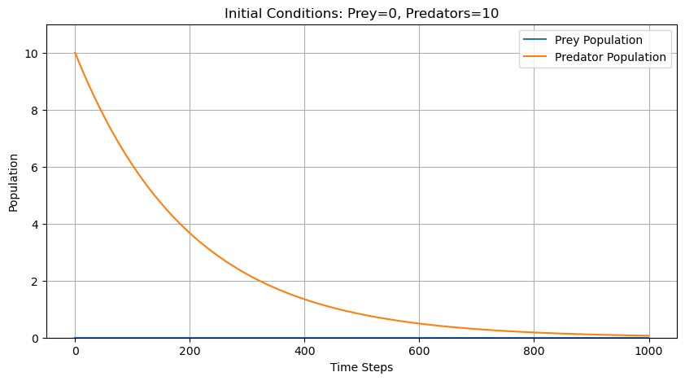

```python
# Intial conditions when prey=0 and predators=10
H, P, Q, H0, P0 = results[4]

plt.figure(figsize=(10, 5))
plt.plot(H, label='Prey Population')
plt.plot(P, label='Predator Population')
plt.title(f'Initial Conditions: Prey={H0}, Predators={P0}')
plt.xlabel('Time Steps')
plt.ylabel('Population')
plt.ylim(0, max(np.max(H), np.max(P)) * 1.1)  # Adjust y-axis limits for better visualization
plt.legend()
plt.grid(True)
plt.show()
```

This time, the graph illustrates a scenario where starting without any prey leads to a rapid decline in the predator population. The predators, lacking a food source, quickly decrease in number, approaching extinction. This situation indicatest the critical dependence of predators on their prey for survival. Without a food source, the predator population cannot sustain itself, let along grow or reproduce. In regards to the quantum variability, it does not change the outcome as the essential element (the prey) that would be influenced by the quantum effect is absent.

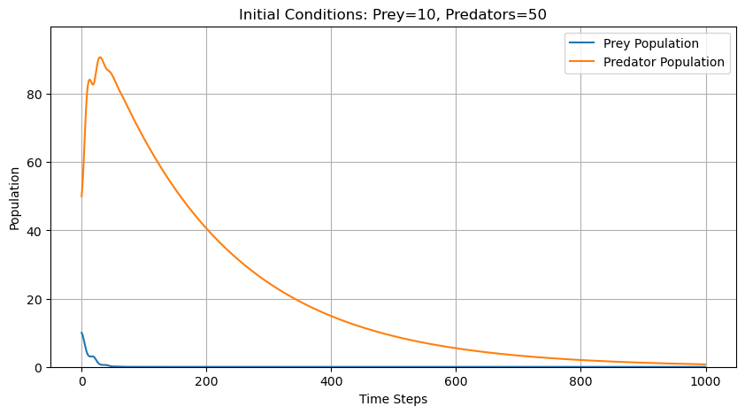

```python
# Intial conditions when prey=10 and predators=50
H, P, Q, H0, P0 = results[5]

plt.figure(figsize=(10, 5))
plt.plot(H, label='Prey Population')
plt.plot(P, label='Predator Population')
plt.title(f'Initial Conditions: Prey={H0}, Predators={P0}')
plt.xlabel('Time Steps')
plt.ylabel('Population')
plt.ylim(0, max(np.max(H), np.max(P)) * 1.1)  # Adjust y-axis limits for better visualization
plt.legend()
plt.grid(True)
plt.show()
```

# Continuous Time Analysis

*Let’s see what happens if we move to continous time now. Express your system as a set of differential equations and, once again, simulate the behaviour of your system.*

*Plot and explain your results, and be sure to point out any differences between discrete and continuous time that you notice. Discuss how your results illuminate the question posed in Part 1.*

For this question, we will express the system using differential equations and simulate it using different solvers. We'll include the use of a basic RK2 (Runge-Kutta 2nd order) method and compare it with another solver.

Given the following continuous-time model formulas:

- $\frac{dH}{dt} = rH - \alpha Q(t)HP$
- $\frac{dP}{dt} = bQ(t)HP - mP$
- $Q(t) = 0.5 + 0.5 \sin(2\pi \omega t)$

Where:

- $H$ represents the prey population.
- $P$ represents the predator population.
- $r, a, b,$ and $m$ are constants describing the growth, predation rate, conversion efficiency, and mortality rate respectively.
- $\omega$ is the frequency of the quantum fluctuation.

We will test the parameters and initial conditions that vary the initial populations of predators and prey to observe the model's sensitivity and dynamics under different ecological scenarios.

To solve the differential equations, importing odeint from scipy.integrate is used. Then we define parameters like the growth rate of the prey ($r$), the predation rate($\alpha$), the conversion efficiency of predators ($b$), predator mortality ($m$), and the frequency of quantum fluctuations ($\omega). These parameters will dictate the dynamics of the model.

```python
from scipy.integrate import odeint
```

```python
# Parameters
r = 0.1  # Prey growth rate
a = 0.02  # Predation rate
b = 0.1  # Predator efficiency
m = 0.05  # Predator mortality
omega = 0.5  # Quantum fluctuation frequency
t = np.linspace(0, 100, 1000)  # Time array
```

The following function defines the differential equations based on the Lotka-Volterra model that was modified to include the quantum fluctuation term $Q(t) = 0.5 + 0.5 \sin(2\pi \omega t)$. This term introduces a time-dependent factor that affects the interaction rates between predator and prey, simulating the impact of quantum mechanics on predator behaviour.

Then we introduce different initial population sizes for predators and prey to explore how varying the starting conditions affect the system dynamics. This helps in understanding the sensitivity and stability of the model under different ecological situations.

```python
# Differential equations
def model(y, t, r, a, b, m, omega):
    H, P = y
    Q = 0.5 + 0.5 * np.sin(2 * np.pi * omega * t)
    dHdt = r * H - a * Q * H * P
    dPdt = b * Q * H * P - m * P
    return [dHdt, dPdt]

# Initial conditions
initial_conditions = [(50, 10), (100, 20), (10, 5)]  # Different pairs of (H0, P0)
```

For the following function, we implement the second-order Runge-Katta method, in which calculates two slopes (k1 and k2) at each step and uses the average to estimate the next value. Both odeint and the RK2 method are used in this case to solve the equations for each set of initial conditions and are compared to validate the RK2 implementation against the odeint solver.

```python
# Implementing RK2 (Midpoint Method)
def rk2(y0, t, dt, model, args):
    ys = [y0]
    for ti in t[:-1]:
        y = ys[-1]
        k1 = np.array(model(y, ti, *args))
        k2 = np.array(model(y + dt * 0.5 * k1, ti + 0.5 * dt, *args))
        y_next = y + dt * k2
        ys.append(y_next)
    return np.array(ys)

# Results storage
odeint_results = []
rk2_results = []

# Running simulations
for H0, P0 in initial_conditions:
    # Solving with odeint
    sol_odeint = odeint(model, [H0, P0], t, args=(r, a, b, m, omega))
    odeint_results.append(sol_odeint)

    # Solving with RK2
    dt = t[1] - t[0]
    sol_rk2 = rk2([H0, P0], t, dt, model, (r, a, b, m, omega))
    rk2_results.append(sol_rk2)
```

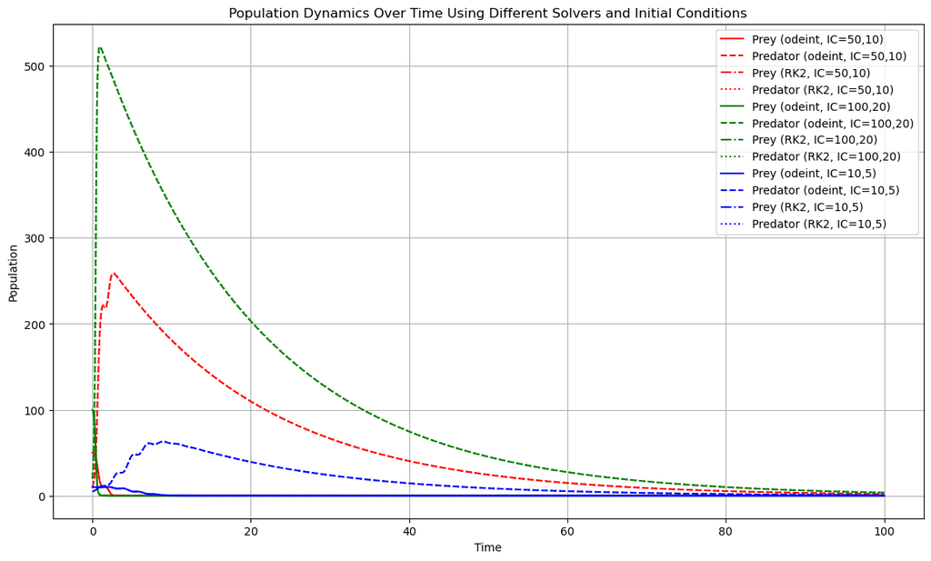

```python
# Plotting results
plt.figure(figsize=(14, 8))
colors = ['r', 'g', 'b']  # Colors for different initial conditions
for i, ((H0, P0), odeint_res, rk2_res) in enumerate(zip(initial_conditions, odeint_results, rk2_results)):
    plt.plot(t, odeint_res[:, 0], color=colors[i], linestyle='-', label=f'Prey (odeint, IC={H0},{P0})')
    plt.plot(t, odeint_res[:, 1], color=colors[i], linestyle='--', label=f'Predator (odeint, IC={H0},{P0})')
    plt.plot(t, rk2_res[:, 0], color=colors[i], linestyle='-.', label=f'Prey (RK2, IC={H0},{P0})')
    plt.plot(t, rk2_res[:, 1], color=colors[i], linestyle=':', label=f'Predator (RK2, IC={H0},{P0})')

plt.title('Population Dynamics Over Time Using Different Solvers and Initial Conditions')
plt.xlabel('Time')
plt.ylabel('Population')
plt.legend()
plt.grid(True)
plt.show()
```

The plot above displays the dynamics of both the predator (P) and prey (H) populations over time, solved using two different methods, in which included importing odeint and implementing the RK2 method, with three sets of initial conditions.

As observed in the plot, both the odeint and RK2 methods show very similar trajectories for the populations, indicating consistent results acorss numerical methods. Additionally, the odeint solver, which uses more complex methods, could potentially handle stiff equations better and may provide more accuracy in more challenging scenarios. However, despite this, the RK2 method seems to hold up well in this model and provides an efficient alternative.

In comparison with the discrete time models, the continuous-time model definitely provides smoother curves, which might show more abrupt changes due to the stepwise nature of its computation. Continuous models seem to better capture the fluid dynamics of ecological processes in this case. Similarly to the discrete time model, the sensitivity of the continuous-time model to quantum fluctuations and initial conditions suggests that even small quantum-level phenomena, if they were to significantly influence biological processes, could lead to considerable effects at the population level, potentially altering the ecosystem's stability.

```python
# Parameters for different scenarios
param_sets = [
    (0.1, 0.02, 0.1, 0.05, 0.5),   # Base case
    (0.05, 0.01, 0.05, 0.1, 0.5),  # Lower growth and higher mortality
    (0.2, 0.03, 0.15, 0.01, 0.5),  # Higher growth and lower mortality
]

# New initial conditions
new_initial_conditions = [
    (50, 0),    # No predators initially
    (0, 10),    # No prey initially
    (100, 100), # High initial populations
    (1, 1),     # Very low initial populations
]
```

```python
# Extend time span for a clearer long-term behavior
t_extended = np.linspace(0, 200, 2000)  # Extended time array

# Storing extended simulation results
extended_results = {}

# Running extended simulations with odeint for clarity and accuracy
for idx, (r, a, b, m, omega) in enumerate(param_sets):
    for H0, P0 in new_initial_conditions:
        key = f"Scenario: Params {idx+1} (r={r}, a={a}, b={b}, m={m}, ω={omega}), IC=(Prey {H0}, Predators {P0})"
        sol = odeint(model, [H0, P0], t_extended, args=(r, a, b, m, omega))
        extended_results[key] = sol
```

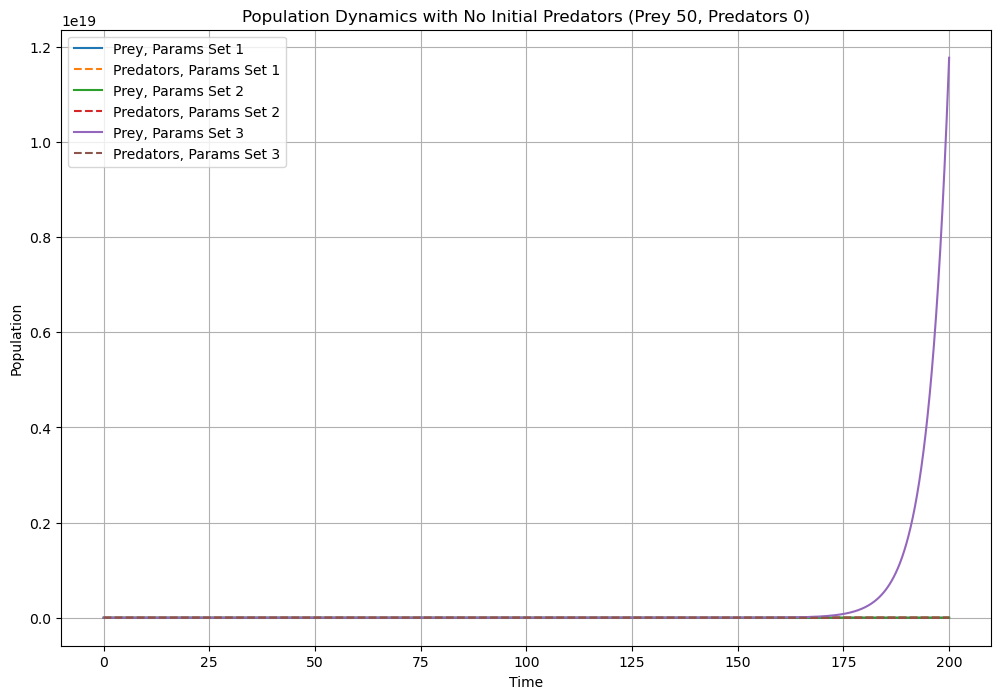

```python
# Isolating and plotting the scenario with no predators initially (IC=(50,0))

# Generate plots for this specific initial condition across all parameter sets
plt.figure(figsize=(12, 8))
for idx, params in enumerate(param_sets):
    # Isolate the solution for the scenario with no predators initially
    key = f"Scenario: Params {idx+1} (r={params[0]}, a={params[1]}, b={params[2]}, m={params[3]}, ω={params[4]}), IC=(Prey 50, Predators 0)"
    data = extended_results[key]

    # Plotting
    plt.plot(t_extended, data[:, 0], label=f'Prey, Params Set {idx+1}')
    plt.plot(t_extended, data[:, 1], '--', label=f'Predators, Params Set {idx+1}')

plt.title('Population Dynamics with No Initial Predators (Prey 50, Predators 0)')
plt.xlabel('Time')
plt.ylabel('Population')
plt.legend()
plt.grid(True)
plt.show()
```

The above plot shows the dynamics of the predator and prey populations over time when there are no predators initially. As observed, this plot is quite similar to the one in Part 2.

In comparison, the prey population shown in the discrete-model plot appears to grow exponentially over the time steps. The predator population remains at zero throughout the simulation, which is consistent with the initial conditions and lack of introduction of predators during the simulation. Similarly for the continuous-time model, the prey population grows exponentially, reflecting the absence of predation pressure. The predators also remain absent, confirming the same behavior across both modeling approaches.

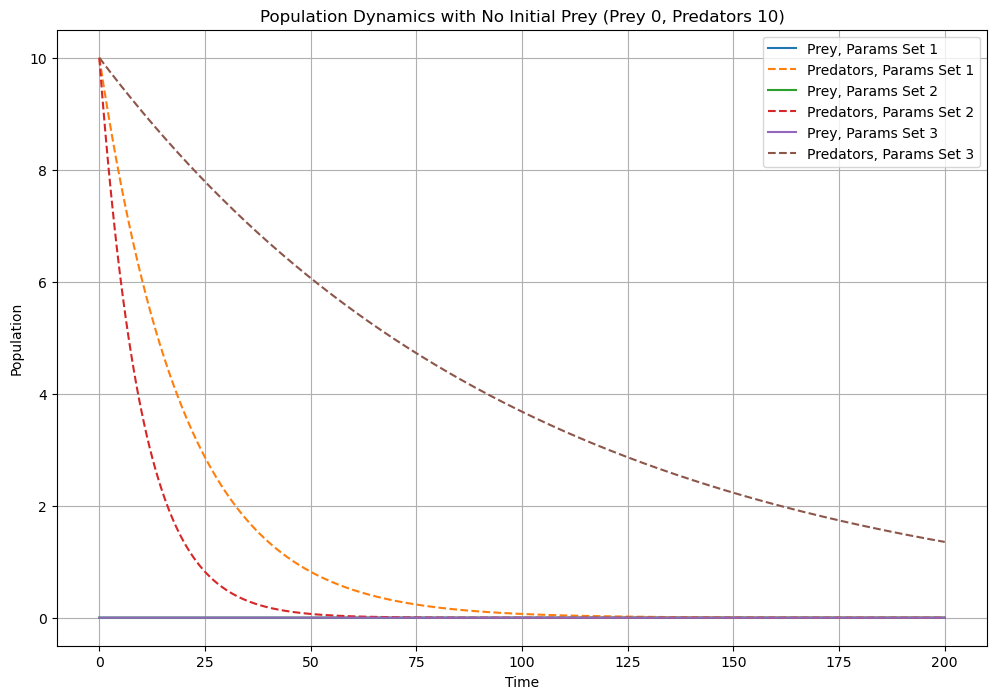

```python
# no prey initially (IC=(0,10))

# Generate plots for this specific initial condition across all parameter sets
plt.figure(figsize=(12, 8))
for idx, params in enumerate(param_sets):
    # Isolate the solution for the scenario with no prey initially
    key = f"Scenario: Params {idx+1} (r={params[0]}, a={params[1]}, b={params[2]}, m={params[3]}, ω={params[4]}), IC=(Prey 0, Predators 10)"
    data = extended_results[key]

    # Plotting
    plt.plot(t_extended, data[:, 0], label=f'Prey, Params Set {idx+1}')
    plt.plot(t_extended, data[:, 1], '--', label=f'Predators, Params Set {idx+1}')

plt.title('Population Dynamics with No Initial Prey (Prey 0, Predators 10)')
plt.xlabel('Time')
plt.ylabel('Population')
plt.legend()
plt.grid(True)
plt.show()
```

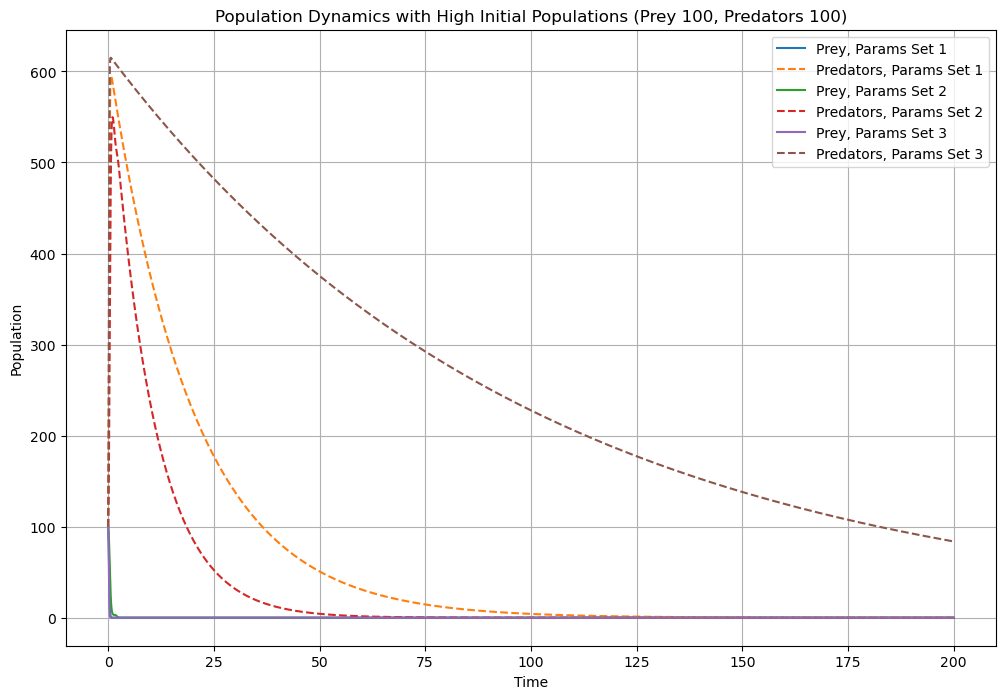

```python
# scenario with high initial populations (IC=(100,100))

# Generate plots for this specific initial condition across all parameter sets
plt.figure(figsize=(12, 8))
for idx, params in enumerate(param_sets):
    # Isolate the solution for the scenario with high initial populations
    key = f"Scenario: Params {idx+1} (r={params[0]}, a={params[1]}, b={params[2]}, m={params[3]}, ω={params[4]}), IC=(Prey 100, Predators 100)"
    data = extended_results[key]

    # Plotting
    plt.plot(t_extended, data[:, 0], label=f'Prey, Params Set {idx+1}')
    plt.plot(t_extended, data[:, 1], '--', label=f'Predators, Params Set {idx+1}')

plt.title('Population Dynamics with High Initial Populations (Prey 100, Predators 100)')
plt.xlabel('Time')
plt.ylabel('Population')
plt.legend()
plt.grid(True)
plt.show()
```

# Steady State Analysis

*Some dynamical systems will eventually converge to a steady state, where the rate of change for each variable is 0. For both, discrete and continuous time, discuss the steady states and how they relate to the systems behaviour.*

*Does the model have any steady states? If so, where are they located? How stable are they? Why? Discuss how your results illuminate the question posed in Part 1.*

*If your model is too involved to meaningfully produce steady state analysis and cobwebbing diagrams, feel free to make some simplifications to your model for this task.*

For this question, we will first analyse the steady states of the continuous-time model. The steady states occur where the derivatives of the population equations are zero as shown below: $$\frac{dH}{dt} = rH - \alpha Q(t)HP = 0$$ $$\frac{dP}{dt} = bQ(t)HP - mP = 0$$

The stability of these steady states would probably require a Jacobian matrix analysis. For oscillating $Q(t)$, stability can vary with time, which might lead to situations where the steady states are not constant but instead cycle or fluctuate depending on $Q(t)$.

For the discrete model, we similarly set the changes in populations to zero: $$ H_{n+1} = H_n + \Delta t \cdot (rH_n - \alpha_n Q_n H_n P_n) = 0 $$ $$ P_{n+1} = P_n + \Delta t \cdot (bQ_n H_n P_n - mP_n) = 0 $$

The stability in discrete models can be checked using eigenvalues of the Jacobian matrix of the difference equations. However, the conditions for stability are generally stricter due to the potential for chaotic behaviour in discrete systems, especially when the time step size is large.

To conduct a meaningful steady state and cobwebbing analysis, we will simplify the model by assuming that $Q(t) = Q$ is constant by removing the time dependency. This allows us to fix the interaction term and focus on the basic predator-prey interactions without the oscillating quantum effect.

```python
import matplotlib.pyplot as plt
import numpy as np
```

```python
# Constants
r = 0.1  # Prey growth rate
a = 0.02  # Predation rate
b = 0.1  # Predator efficiency
m = 0.05  # Predator mortality
Q = 1    # Constant quantum effect for simplification
```

The following functions will calculate the rate of change in the population of prey (H) and predators (P), integrating the constant quantum effect $Q$. The quantum effect $Q$ directly scales the interaction terms, fitting the question's focus by showing how such scaling might shift dynamics.

```python
# Model equations for continuous time
def dH_dt(H, P):
    return r * H - a * Q * H * P

def dP_dt(H, P):
    return b * Q * H * P - m * P

# Phase plane analysis
H_values = np.linspace(0, 100, 400)
P_values = np.linspace(0, 100, 400)
H, P = np.meshgrid(H_values, P_values)
dH = dH_dt(H, P)
dP = dP_dt(H, P)

# Nullclines where dH/dt = 0 and dP/dt = 0
H_nullcline = m / (b * Q)
P_nullcline = r / (a * Q)
```

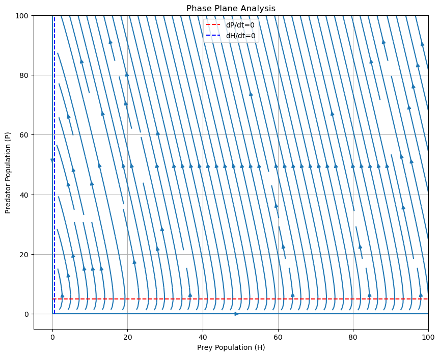

```python
plt.figure(figsize=(10, 8))
plt.streamplot(H, P, dH, dP, density=1.5)
plt.plot(H_values, P_nullcline * np.ones_like(H_values), 'r--', label='dP/dt=0')
plt.plot(H_nullcline * np.ones_like(P_values), P_values, 'b--', label='dH/dt=0')
plt.xlabel('Prey Population (H)')
plt.ylabel('Predator Population (P)')
plt.title('Phase Plane Analysis')
plt.legend()
plt.grid(True)
plt.show()
```

The plot above shows the phase plane of the predator-prey dynamics with constant quantum influence $Q$, which simplifies the interaction terms. From the plot shown, the arrows indicate the direction of the system's trajectories in the phase plane, showing how the populations of prey (H) and predators (P) evolve over time. Each arrow points in the direction that the system will evolve if it starts from that point. The length and direction of the arrows indicate how quickly and in what direction the populations are changing. The long arrows suggest rapid changes, while short arrows indicate slower changes.

With constant $Q$, the model behaves as a traditional Lotka-Volterra system but scaled by the quantum effect. The variability introduced by oscillating $Q(t)$ in more complex scenarios would further influence these dynamics, potentially causing the equilibrium points to shift or the system's stability to change over time.

To delve even deeper into the steady state analysis and better visualise the dynamics of the predator-prey model, we can explore several additional types of plots. The first of which will be plotting a time series from a specific intitial condition and a cobweb plot for a simple discrete version of the model, assuming a constant $Q$ for simplicity. This will show how populations evolve from different initial conditions toward steady states over time and to also show the behaviour of the discrete-time model by iterating the model equations and visually tracing the path toward or away from equilibrium.

```python
# Define the simplified discrete model functions for cobwebbing
def discrete_prey(H, P):
    return H + dt * (r * H - a * Q * H * P)

def discrete_predator(H, P):
    return P + dt * (b * Q * H * P - m * P)
```

```python
# Time series simulation
def simulate_time_series(H0, P0, steps=500):
    Hs, Ps = [H0], [P0]
    for _ in range(steps):
        H_next = discrete_prey(Hs[-1], Ps[-1])
        P_next = discrete_predator(Hs[-1], Ps[-1])
        Hs.append(H_next)
        Ps.append(P_next)
    return Hs, Ps
```

```python
# Cobwebbing function
def cobwebbing(H0, P0, steps=50):
    Hs, Ps = [H0], [P0]
    plt.figure(figsize=(12, 6))

    # Plotting H_n+1 = H_n line
    plt.plot([0, 100], [0, 100], 'k--', label='H[n+1] = H[n]')

    # Performing cobwebbing
    for _ in range(steps):
        H_next = discrete_prey(Hs[-1], Ps[-1])
        P_next = discrete_predator(Hs[-1], Ps[-1])
        plt.plot([Hs[-1], Hs[-1]], [Hs[-1], H_next], 'r')  # Vertical
        plt.plot([Hs[-1], H_next], [H_next, H_next], 'r')  # Horizontal
        Hs.append(H_next)
        Ps.append(P_next)

    plt.xlabel('H[n]')
    plt.ylabel('H[n+1]')
    plt.title('Cobwebbing Plot for Prey Population')
    plt.grid(True)
    plt.legend()
    plt.show()
```

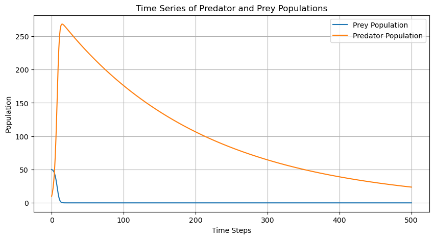

```python
# Running simulations
H0, P0 = 50, 10  # Initial conditions
Hs, Ps = simulate_time_series(H0, P0)

# Plot time series
plt.figure(figsize=(10, 5))
plt.plot(Hs, label='Prey Population')
plt.plot(Ps, label='Predator Population')
plt.title('Time Series of Predator and Prey Populations')
plt.xlabel('Time Steps')
plt.ylabel('Population')
plt.legend()
plt.grid(True)
plt.show()
```

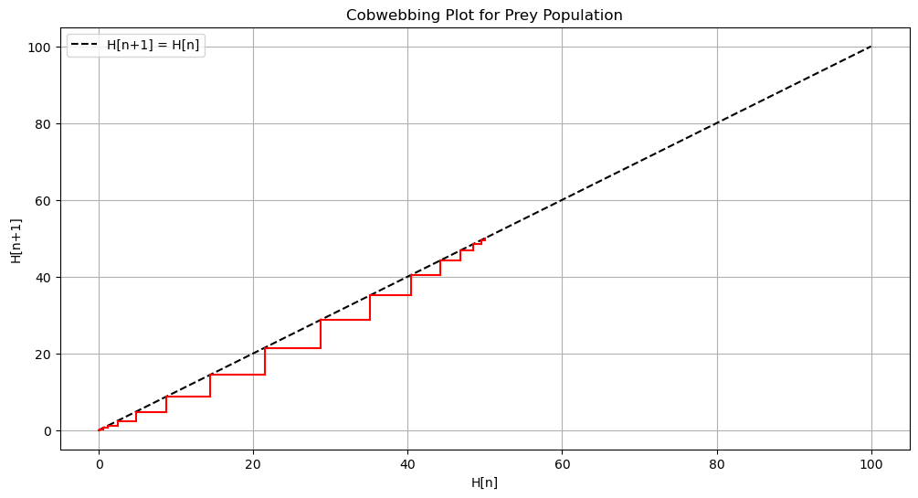

```python
# Generate cobweb plot
cobwebbing(H0, P0)
```

The cobwebbing plot is designed to analyse the stability and behaviour of the prey population in a discrete model framework. Specifically, we are looking at the relationship between $H[n]$ and $H[n+1]$.

In the context of the question about quantum influence, the results from these plots indicate that the inclusion of quantum effects, even simplified to a constant $Q$ here, highlights how sensitive the system's dynamics can be to changes in predation efficiency and other factors influenced by quantum mechanics. The analysis also supports the idea that quantum fluctuations could introduce additional complexity into the predator-prey dynamics, and could potentially alter the stability, leading to different population cycling behaviours.